# Teste em mapa de Kanto

Celso Mattheus Cantanhede Silva

10/07/2019

# Teste de técnicas de criação de Isocronos em mapa de teste

O objetivo, neste teste, é aplicar técnicas de custo de movimentação em mapas em grade ( *raster maps* ), para se responder qual a proximidade, a partir de cada ponto da grade, de um local de interesse definido.

[figure not shown]

Os terrenos disponíveis para os jogadores forma classificados e, para cada tipo de terreno, foi definida uma velocidade de travessia, análoga aos terrenos descritos no Malaria World Atlas, utilizado como referência no TCC.

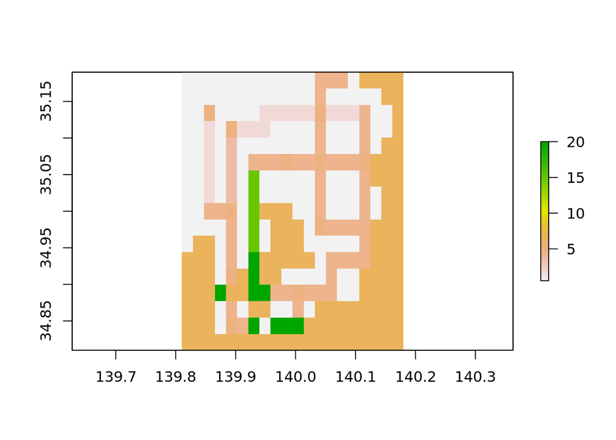

```r
#Fatores de tipo de terreno
kanto_info <- read.csv('dataframe_kanto.csv', sep=';', header=F)
terrain <- data.frame(
            num_factor = c(0,1,2,3,4,5,6,7),
            terrain = c('SE','LD','CT','RM','RC','RG','RF','SH'),
            speed = c(6.5,0.55,5,1.65,15,4.5,3.5,20)
            )
kanto_terrain <- kanto_info %>%
                mutate(V1 = as.character(V1)) %>%
                left_join(., terrain, by=c('V1' = 'terrain')) %>%
                dplyr::select(num_factor) %>%
                rename(terrain = num_factor) %>%
                as.matrix(.)
dim(kanto_terrain) <- c(17, 20)

#fatores de velocidade
kanto_speed <- kanto_info %>%
  mutate(V1 = as.character(V1)) %>%
  left_join(., terrain, by=c('V1' = 'terrain')) %>%
  dplyr::select(speed) %>%
  as.matrix(.)
dim(kanto_speed) <- c(17, 20)

#raster de terreno
kanto <- raster(kanto_speed,
                xmn=139.81,
                xmx=140.18,
                ymn=34.81,
                ymx=35.19,
                crs=CRS("+proj=longlat +datum=WGS84")
                )

plot(kanto)
```

O local de interesse definido foram os chamados *centros pokémon*, únicos locais do jogo em que se pode regenerar os health points, e, como tal, pontos de retorno contínuo dos jogadores.

**A pergunta a ser respondida pela análise então, fica: quais são as regiões dos mapa mais próximas e quais as regiões mais distantes de um *centro pokémon* qualquer?**

Incluindo-se ao mapa as localizações geográficas dos centros pokémons, podemos utilizar a função *accCost* para responder essa questão.

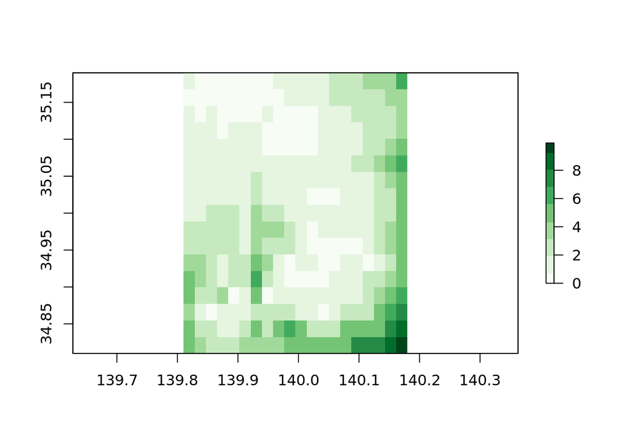

```r
#matriz de transição: custo de velocidade de cada tipo de terreno
custoMov <- gdistance::transition(kanto, function(x) 1/mean(x), 8)
custoMov <- gdistance::geoCorrection(custoMov)

#localização dos pokécenters
grid_centers <- rbind(
c(3,3),
c(5,4),
c(5,16),
c(8,4),
c(10,6),
c(11,14),
c(13,3),
c(13,6),
c(13,10),
c(17,6))

convCoord <- function(vec){
  #função para por os centros pokémons nas coordenadas corretas
  delta_x <- (140.18-139.81)/21
  delta_y <- (35.19-34.81)/18
  result <- cbind(vec[,1] * delta_x + 139.81, vec[,2] * delta_y+34.81)
  return(result)
}

kanto_centers <- convCoord(grid_centers)
CostMap <- accCost(custoMov, kanto_centers)
CostMap <- CostMap/7000

plot(CostMap, col=brewer.pal(n= 9, name='Greens'))
```

Dessa forma, podemos visualizar, lado a lado, a influência da existência de infraestruras que permitam velocidades maiores na configuração das regiões de mais e menos acesso aos *centros pokémon* .

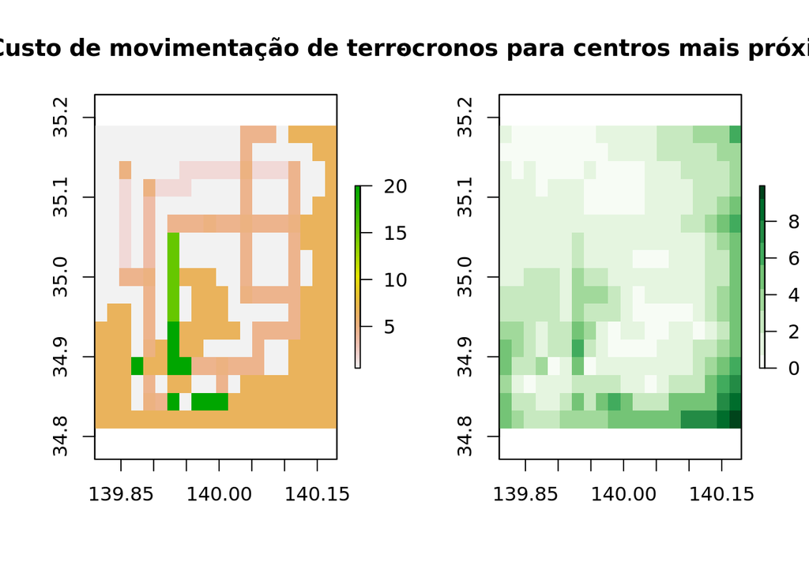

```r
par(mfrow=c(1, 2))
plot(kanto, main='Custo de movimentação de terreno')
plot(CostMap, main='Isocronos para centros mais próximos', col=brewer.pal(n= 9, name='Greens'))
```